# Homework 5

Each part of each question will be 5pts, there are 10 parts, so 50pts total.

## 1. Interpreting logistic regression 15pts

Suppose we collect data for a group of students in a statistics class with independent variables $X_{1}=\text{hours studied}$, $X_{2}=\text{GPA}$, and binary response variable
$$Y= \begin{cases} 1 &\mbox{ if student received an A} \\
0 &\mbox{ otherwise. }
\end{cases}$$
Suppose that we fit a logistic regression model to the data, predicting $Y$ from $X_1$ and $X_2$ (and an intercept term) and produce estimated coefficients $\hat{\beta}_{0}=-6, \hat{\beta}_{1}=0.05, \hat{\beta}_{2}=1$.

### Part a) Logistic regression and probability

According to our fitted model, what is the probability that a student receives an A if they study for $40$ hours and have a GPA of $3.5$?

```r
P = 1 / (1 + exp(-(-6+0.05*40+1*3.5)))

P
```

```
## [1] 0.3775407
```

### Part b) Interpreting coefficients

According to our fitted model, an additional hour spent studying is associated with *how much* of an increase in the log odds of receiving an A?

```r
x1 = 0.05

x1
```

```
## [1] 0.05
```

### Part c) “Inverting” logistic regression probabilities

According to our fitted model, how many hours would the student in Part (a) need to study to have a $50\%$ chance of getting an A in the class? That is, keeping GPA fixed at $3.5$, how many hours of study are needed so that the probability of an A is $50\%$? If you aren’t up for the math, feel free to find an approximate solution via guess-and-check in R.

0.5 = 1 / (1 + exp(-(-6+0.05*HOURS+1*3.5)))  
solve for HOURS

1 + exp(-(-6+0.05HOURS+3.5)) = 2  
exp(-(-6+0.05HOURS+3.5)) = 1  
-(-6+0.05HOURS+3.5) = ln(1)  
-(-6+0.05HOURS+3.5) = 0  
−6+0.05HOURS+3.5 = 0  
0.05HOURS = 2.5  
HOURS = 50

```r
# calculations are above, format is bad sorry
#TODO: code for calculation goes here, if necessary.
HOURS = 50
HOURS
```

```
## [1] 50
```

## 2. `mtcars` one more time 10pts

Let’s take yet another look at the `mtcars` data set. Recall that the columns of this data set are:

```r
names(mtcars)
```

```
##  [1] "mpg"  "cyl"  "disp" "hp"   "drat" "wt"   "qsec" "vs"   "am"   "gear"
## [11] "carb"
```

The `am` column encodes whether a car is automatic (`0`) or manual (`1`). Let’s build a model to predict whether a car is manual or automatic.

### Part a) Fitting/interpreting a model

Fit a logistic regression model to regress `am` against the `drat` and `disp` (and an intercept term).

```r
model = glm(am ~ drat + disp, data = mtcars, family = binomial)

summary(model)
```

```
##
## Call:
## glm(formula = am ~ drat + disp, family = binomial, data = mtcars)
##
## Coefficients:
##               Estimate Std. Error z value Pr(>|z|)
## (Intercept) -17.638452   9.165482  -1.924   0.0543 .
## drat          4.879396   2.268115   2.151   0.0315 *
## disp         -0.004153   0.006621  -0.627   0.5305
## ---
## Signif. codes:  0 '***' 0.001 '**' 0.01 '*' 0.05 '.' 0.1 ' ' 1
##
## (Dispersion parameter for binomial family taken to be 1)
##
##     Null deviance: 43.230  on 31  degrees of freedom
## Residual deviance: 21.268  on 29  degrees of freedom
## AIC: 27.268
##
## Number of Fisher Scoring iterations: 6
```

Which coefficients (if any) are statistically significantly different from zero at the $\alpha=0.05$ level? Interpret the meaning of the estimated coefficient(s) that is/are statistically significantly different from zero.

### Part b) Modifying/assessing the model

Choose one of the statistically significant predictors above and re-fit a model using *only* that variable (and an intercept) to predict `am`. We’ll see how to compare the quality of this model to the one from Part (a) when we talk about cross-validation (CV) in upcoming lectures. For now, compare the estimated coefficient of this variable in both models. Is there a sizable difference?

Does anything else notable change about the model?

```r
model = glm(am ~ 1 + disp, data = mtcars, family = binomial)

summary(model)
```

```
##
## Call:
## glm(formula = am ~ 1 + disp, family = binomial, data = mtcars)
##
## Coefficients:
##              Estimate Std. Error z value Pr(>|z|)
## (Intercept)  2.630849   1.050170   2.505  0.01224 *
## disp        -0.014604   0.005168  -2.826  0.00471 **
## ---
## Signif. codes:  0 '***' 0.001 '**' 0.01 '*' 0.05 '.' 0.1 ' ' 1
##
## (Dispersion parameter for binomial family taken to be 1)
##
##     Null deviance: 43.230  on 31  degrees of freedom
## Residual deviance: 29.732  on 30  degrees of freedom
## AIC: 33.732
##
## Number of Fisher Scoring iterations: 5
```

The p-value went from 0.5305 in the previous model to 0.00471 now in the current model, that is a large change

Choose one of the statistically significant predictors above. Use `ggplot2` to plot `am` as a function of this predictor, and overlay a curve describing the logistic regression output when using *only* this predictor to predict `am` (i.e., the model from Part c above).

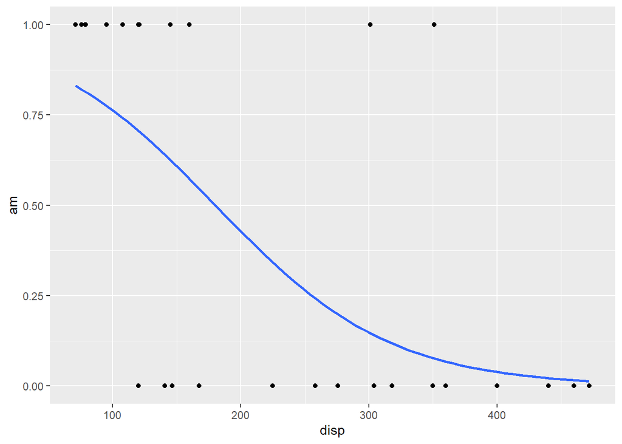

```r
library(ggplot2)

model = glm(am ~ 1 + disp, data = mtcars, family = binomial)

ggplot(mtcars, aes(x=disp, y=am) ) +
  geom_point() +
  geom_smooth(formula='y ~ 1+x', se=FALSE,
                       method='glm',
                       method.args=list(family = "binomial"));
```

## 3. Guided k-fold CV exercise 15pts

In this exercise, we will guide you through an exercise where you are asked to use k-fold cross validation to evaluate the performance of several models.

For this exercise we will use the “Swiss Fertility and Socioeconomic Indicators (1888)” dataset from the `datasets` package, which is loaded below. (To view the help page, run `?datasets::swiss` in your console). We will be using `Fertility` as our response variable.

```r
swiss = datasets::swiss
```

### Part a) Understanding/visualizing data

Read the help page and briefly “introduce” this dataset. Specifically, explain where the data comes from, what variables it contains, and why should people care about the dataset.

Switzerland, in 1888, was entering a period known as the demographic transition; i.e., its fertility was beginning to fall from the high level typical of underdeveloped countries. The data set is a standardized fertility measure and socio-economic indicators for each of 47 French-speaking provinces of Switzerland at about 1888. A data frame with 47 observations on 6 variables, each of which is in percent, i.e., in [0,100].

[1] Fertility Ig, ‘common standardized fertility measure’ [2] Agriculture % of males involved in agriculture as occupation [3] Examination % draftees receiving highest mark on army examination [4] Education % education beyond primary school for draftees. [5] Catholic % ‘catholic’ (as opposed to ‘protestant’). [6] Infant.Mortality live births who live less than 1 year. All variables but ‘Fertility’ give proportions of the population.

Produce one or some visualizations of the data. Do your best here to try to use your plots to help your viewer best understand the structure and patterns of this dataset. Choose your plots carefully and briefly explain what each plot tells you about the data.

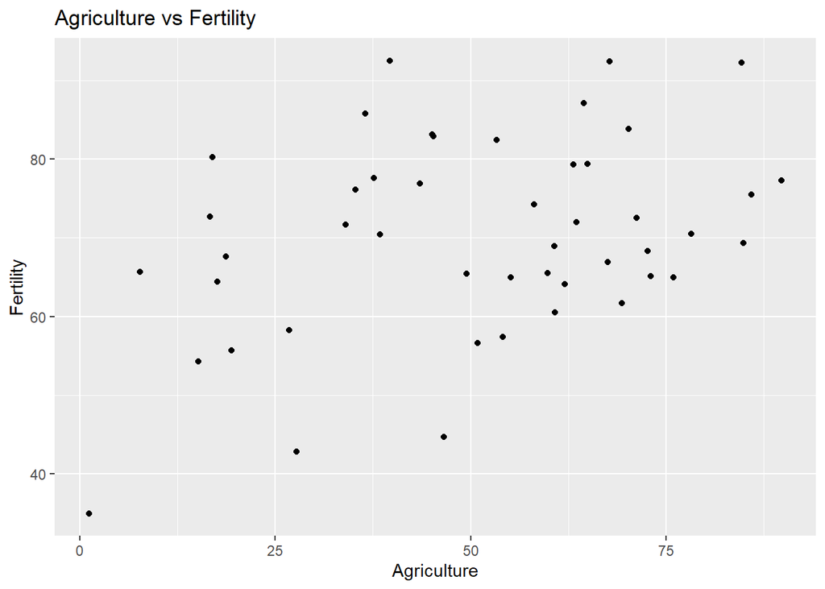

```r
library(ggplot2)
ggplot(swiss, aes(x = Agriculture, y = Fertility)) + geom_point() +
  labs(title = "Agriculture vs Fertility",
       x = "Agriculture",
       y = "Fertility")
```

### Part b) Starting with basic lm

Compare a model with all predictors with no interactions with 2 other models of YOUR choice. Fit all 3 models, show their summary outputs, and briefly comment on which one you think might perform the best when used for future predictions and why.

```r
model1 = lm(Fertility ~ Agriculture + Examination + Education + Catholic + Infant.Mortality, data = swiss)
summary(model1)
```

```
##
## Call:
## lm(formula = Fertility ~ Agriculture + Examination + Education +
##     Catholic + Infant.Mortality, data = swiss)
##
## Residuals:
##      Min       1Q   Median       3Q      Max
## -15.2743  -5.2617   0.5032   4.1198  15.3213
##
## Coefficients:
##                  Estimate Std. Error t value Pr(>|t|)
## (Intercept)      66.91518   10.70604   6.250 1.91e-07 ***
## Agriculture      -0.17211    0.07030  -2.448  0.01873 *
## Examination      -0.25801    0.25388  -1.016  0.31546
## Education        -0.87094    0.18303  -4.758 2.43e-05 ***
## Catholic          0.10412    0.03526   2.953  0.00519 **
## Infant.Mortality  1.07705    0.38172   2.822  0.00734 **
## ---
## Signif. codes:  0 '***' 0.001 '**' 0.01 '*' 0.05 '.' 0.1 ' ' 1
##
## Residual standard error: 7.165 on 41 degrees of freedom
## Multiple R-squared:  0.7067, Adjusted R-squared:  0.671
## F-statistic: 19.76 on 5 and 41 DF,  p-value: 5.594e-10
```

```r
model2 <- lm(Fertility ~ Agriculture + Catholic, data = swiss)
summary(model2)
```

```
##
## Call:
## lm(formula = Fertility ~ Agriculture + Catholic, data = swiss)
##
## Residuals:
##     Min      1Q  Median      3Q     Max
## -29.863  -6.350   1.136   7.476  18.056
##
## Coefficients:
##             Estimate Std. Error t value Pr(>|t|)
## (Intercept) 59.86392    3.98754  15.013   <2e-16 ***
## Agriculture  0.10953    0.07848   1.396   0.1698
## Catholic     0.11496    0.04274   2.690   0.0101 *
## ---
## Signif. codes:  0 '***' 0.001 '**' 0.01 '*' 0.05 '.' 0.1 ' ' 1
##
## Residual standard error: 11.07 on 44 degrees of freedom
## Multiple R-squared:  0.2483, Adjusted R-squared:  0.2141
## F-statistic: 7.266 on 2 and 44 DF,  p-value: 0.001876
```

```r
model3 <- lm(Fertility ~ Examination + Education, data = swiss)
summary(model3)
```

```
##
## Call:
## lm(formula = Fertility ~ Examination + Education, data = swiss)
##
## Residuals:
##      Min       1Q   Median       3Q      Max
## -15.9935  -6.8894  -0.3621   7.1640  19.2634
##
## Coefficients:
##             Estimate Std. Error t value Pr(>|t|)
## (Intercept)  85.2533     3.0855  27.630   <2e-16 ***
## Examination  -0.5572     0.2319  -2.402   0.0206 *
## Education    -0.5395     0.1924  -2.803   0.0075 **
## ---
## Signif. codes:  0 '***' 0.001 '**' 0.01 '*' 0.05 '.' 0.1 ' ' 1
##
## Residual standard error: 8.982 on 44 degrees of freedom
## Multiple R-squared:  0.5055, Adjusted R-squared:  0.483
## F-statistic: 22.49 on 2 and 44 DF,  p-value: 1.87e-07
```

### Part c) Estimating MSE using CV

Now, we are going to actually estimate the MSE of each model with K-fold cross validation. First we’re going to set a seed and import the `caret` package (it should be already installed since it’s a prerequisite for many other packages, but if it’s not for some reason, you can install it with `install.packages("caret")`)

```r
set.seed(1)
library(caret)
```

Next, use the following chunk, which already has `method` set to `lm`, `data` set to the `swiss` data set, and validation method set to use 5-fold CV, to estimate the MSE of each of your models. All you need to do is add in a formula for your model and repeat for all 3 models you have.

```r
model1 = train(Fertility ~ Agriculture + Examination + Education + Catholic + Infant.Mortality, method="lm", data=swiss, trControl = trainControl(method="cv", number=5))
print(summary(model1))
```

```
##
## Call:
## lm(formula = .outcome ~ ., data = dat)
##
## Residuals:
##      Min       1Q   Median       3Q      Max
## -15.2743  -5.2617   0.5032   4.1198  15.3213
##
## Coefficients:
##                  Estimate Std. Error t value Pr(>|t|)
## (Intercept)      66.91518   10.70604   6.250 1.91e-07 ***
## Agriculture      -0.17211    0.07030  -2.448  0.01873 *
## Examination      -0.25801    0.25388  -1.016  0.31546
## Education        -0.87094    0.18303  -4.758 2.43e-05 ***
## Catholic          0.10412    0.03526   2.953  0.00519 **
## Infant.Mortality  1.07705    0.38172   2.822  0.00734 **
## ---
## Signif. codes:  0 '***' 0.001 '**' 0.01 '*' 0.05 '.' 0.1 ' ' 1
##
## Residual standard error: 7.165 on 41 degrees of freedom
## Multiple R-squared:  0.7067, Adjusted R-squared:  0.671
## F-statistic: 19.76 on 5 and 41 DF,  p-value: 5.594e-10
```

```r
model2 = train(Fertility ~ Agriculture + Catholic, method="lm", data=swiss, trControl = trainControl(method="cv", number=5))

model3 = train(Fertility ~ Examination + Education, method="lm", data=swiss, trControl = trainControl(method="cv", number=5))
print(summary(model3))
```

```
##
## Call:
## lm(formula = .outcome ~ ., data = dat)
##
## Residuals:
##      Min       1Q   Median       3Q      Max
## -15.9935  -6.8894  -0.3621   7.1640  19.2634
##
## Coefficients:
##             Estimate Std. Error t value Pr(>|t|)
## (Intercept)  85.2533     3.0855  27.630   <2e-16 ***
## Examination  -0.5572     0.2319  -2.402   0.0206 *
## Education    -0.5395     0.1924  -2.803   0.0075 **
## ---
## Signif. codes:  0 '***' 0.001 '**' 0.01 '*' 0.05 '.' 0.1 ' ' 1
##
## Residual standard error: 8.982 on 44 degrees of freedom
## Multiple R-squared:  0.5055, Adjusted R-squared:  0.483
## F-statistic: 22.49 on 2 and 44 DF,  p-value: 1.87e-07
```

```r
RMSE1 = sqrt(model1$results$RMSE)
RMSE2 = sqrt(model2$results$RMSE)
RMSE3 = sqrt(model3$results$RMSE)

RMSE1
```

```
## [1] 2.781426
```

```r
RMSE2
```

```
## [1] 3.240415
```

```r
RMSE3
```

```
## [1] 3.071985
```

Once you have your models fitted, use `print( )` to show the summary statistics for each model. Report the RMSE for each model, which is the square root of the MSE. Which of these models performs the best? Which performed the worst? Do these results agree with your expectations?

Bonus: repeat the above step, using `trControl = trainControl(method="repeatedcv", number=5, repeats=3)` which repeats each CV analysis 3times and averages out each run to get a more stable estimate of the MSE. Compare the results with the unrepeated MSE estimates. How do they compare?

```r
# with trControl repeats = 3

model11 = train(Fertility ~ Agriculture + Examination + Education + Catholic + Infant.Mortality, method="lm", data=swiss, trControl = trainControl(method="repeatedcv", number=5, repeats=3))
print(summary(model11))
```

```
##
## Call:
## lm(formula = .outcome ~ ., data = dat)
##
## Residuals:
##      Min       1Q   Median       3Q      Max
## -15.2743  -5.2617   0.5032   4.1198  15.3213
##
## Coefficients:
##                  Estimate Std. Error t value Pr(>|t|)
## (Intercept)      66.91518   10.70604   6.250 1.91e-07 ***
## Agriculture      -0.17211    0.07030  -2.448  0.01873 *
## Examination      -0.25801    0.25388  -1.016  0.31546
## Education        -0.87094    0.18303  -4.758 2.43e-05 ***
## Catholic          0.10412    0.03526   2.953  0.00519 **
## Infant.Mortality  1.07705    0.38172   2.822  0.00734 **
## ---
## Signif. codes:  0 '***' 0.001 '**' 0.01 '*' 0.05 '.' 0.1 ' ' 1
##
## Residual standard error: 7.165 on 41 degrees of freedom
## Multiple R-squared:  0.7067, Adjusted R-squared:  0.671
## F-statistic: 19.76 on 5 and 41 DF,  p-value: 5.594e-10
```

```r
model22 = train(Fertility ~ Agriculture + Catholic, method="lm", data=swiss, trControl = trainControl(method="repeatedcv", number=5, repeats=3))
print(summary(model22))
```

```
##
## Call:
## lm(formula = .outcome ~ ., data = dat)
##
## Residuals:
##     Min      1Q  Median      3Q     Max
## -29.863  -6.350   1.136   7.476  18.056
##
## Coefficients:
##             Estimate Std. Error t value Pr(>|t|)
## (Intercept) 59.86392    3.98754  15.013   <2e-16 ***
## Agriculture  0.10953    0.07848   1.396   0.1698
## Catholic     0.11496    0.04274   2.690   0.0101 *
## ---
## Signif. codes:  0 '***' 0.001 '**' 0.01 '*' 0.05 '.' 0.1 ' ' 1
##
## Residual standard error: 11.07 on 44 degrees of freedom
## Multiple R-squared:  0.2483, Adjusted R-squared:  0.2141
## F-statistic: 7.266 on 2 and 44 DF,  p-value: 0.001876
```

```r
model33 = train(Fertility ~ Examination + Education, method="lm", data=swiss, trControl = trainControl(method="repeatedcv", number=5, repeats=3))
print(summary(model33))
```

```
##
## Call:
## lm(formula = .outcome ~ ., data = dat)
##
## Residuals:
##      Min       1Q   Median       3Q      Max
## -15.9935  -6.8894  -0.3621   7.1640  19.2634
##
## Coefficients:
##             Estimate Std. Error t value Pr(>|t|)
## (Intercept)  85.2533     3.0855  27.630   <2e-16 ***
## Examination  -0.5572     0.2319  -2.402   0.0206 *
## Education    -0.5395     0.1924  -2.803   0.0075 **
## ---
## Signif. codes:  0 '***' 0.001 '**' 0.01 '*' 0.05 '.' 0.1 ' ' 1
##
## Residual standard error: 8.982 on 44 degrees of freedom
## Multiple R-squared:  0.5055, Adjusted R-squared:  0.483
## F-statistic: 22.49 on 2 and 44 DF,  p-value: 1.87e-07
```

```r
RMSE11 = sqrt(model11$results$RMSE)
RMSE22 = sqrt(model22$results$RMSE)
RMSE33 = sqrt(model33$results$RMSE)

RMSE11
```

```
## [1] 2.758941
```

```r
RMSE22
```

```
## [1] 3.331087
```

```r
RMSE33
```

```
## [1] 3.079989
```

## 5. Variable selection with `Carseats` 10pts

This question should be answered using the `Carseats` dataset from the `ISLR` package. If you do not have it, make sure to install it.

```r
library(ISLR)

Carseats = ISLR::Carseats

# you should read the help page by running ?Carseats
# we can also peek at the data frame before using it
str(Carseats)
```

```
## 'data.frame':    400 obs. of  11 variables:
##  $ Sales      : num  9.5 11.22 10.06 7.4 4.15 ...
##  $ CompPrice  : num  138 111 113 117 141 124 115 136 132 132 ...
##  $ Income     : num  73 48 35 100 64 113 105 81 110 113 ...
##  $ Advertising: num  11 16 10 4 3 13 0 15 0 0 ...
##  $ Population : num  276 260 269 466 340 501 45 425 108 131 ...
##  $ Price      : num  120 83 80 97 128 72 108 120 124 124 ...
##  $ ShelveLoc  : Factor w/ 3 levels "Bad","Good","Medium": 1 2 3 3 1 1 3 2 3 3 ...
##  $ Age        : num  42 65 59 55 38 78 71 67 76 76 ...
##  $ Education  : num  17 10 12 14 13 16 15 10 10 17 ...
##  $ Urban      : Factor w/ 2 levels "No","Yes": 2 2 2 2 2 1 2 2 1 1 ...
##  $ US         : Factor w/ 2 levels "No","Yes": 2 2 2 2 1 2 1 2 1 2 ...
```

```r
head(Carseats)
```

```
##   Sales CompPrice Income Advertising Population Price ShelveLoc Age Education
## 1  9.50       138     73          11        276   120       Bad  42        17
## 2 11.22       111     48          16        260    83      Good  65        10
## 3 10.06       113     35          10        269    80    Medium  59        12
## 4  7.40       117    100           4        466    97    Medium  55        14
## 5  4.15       141     64           3        340   128       Bad  38        13
## 6 10.81       124    113          13        501    72       Bad  78        16
##   Urban  US
## 1   Yes Yes
## 2   Yes Yes
## 3   Yes Yes
## 4   Yes Yes
## 5   Yes  No
## 6    No Yes
```

### Part a) Visualizing/fitting

First, make some visualizations of the dataset to help set the stage for the rest of the analysis. Try to pick plots to show that are interesting informative.

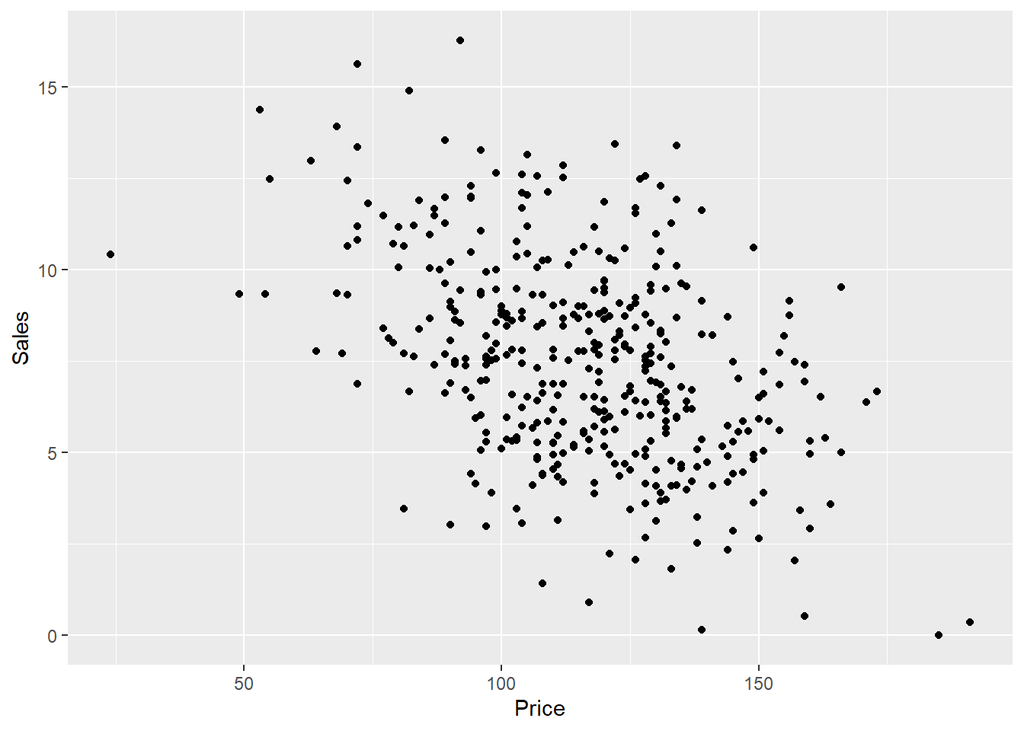

```r
ggplot(Carseats, aes(x = Price, y = Sales)) +
  geom_point()
```

Using some variable selection method (stepwise, LASSO, ridge, or just manually comparing a preselected of models using their MSEs), choose a set of predictors to use to predict `Sales`. Try to find the best model that you can that explains the data well and doesn’t have useless predictors. Explain the choices you made and show the final model.

```r
library(glmnet)
y = Carseats[,1] # Grab just the first column
# ... and the predictors are everything else.
x = Carseats[, -c(1)]
carseats_lasso_lambda0 = glmnet(x, y, alpha = 1, lambda=0.71)
coef(carseats_lasso_lambda0)
```

```
## 11 x 1 sparse Matrix of class "dgCMatrix"
##                      s0
## (Intercept) 10.10694162
## CompPrice    .
## Income       .
## Advertising  0.01122961
## Population   .
## Price       -0.02318861
## ShelveLoc    .
## Age          .
## Education    .
## Urban        .
## US           .
```

Using LASSO at alpha = 1, I incrementally increased lambda starting from 0 to set coefficients of predictors to 0, finally at lambda = 0.71, only 2 predictors were not 0: Advertising and Price

```r
vanilla_lm = lm(Sales ~ Advertising + Price, Carseats)
summary(vanilla_lm)
```

```
##
## Call:
## lm(formula = Sales ~ Advertising + Price, data = Carseats)
##
## Residuals:
##     Min      1Q  Median      3Q     Max
## -7.9011 -1.5470 -0.0223  1.5361  6.3748
##
## Coefficients:
##              Estimate Std. Error t value Pr(>|t|)
## (Intercept) 13.003427   0.606850  21.428  < 2e-16 ***
## Advertising  0.123107   0.018079   6.809 3.64e-11 ***
## Price       -0.054613   0.005078 -10.755  < 2e-16 ***
## ---
## Signif. codes:  0 '***' 0.001 '**' 0.01 '*' 0.05 '.' 0.1 ' ' 1
##
## Residual standard error: 2.399 on 397 degrees of freedom
## Multiple R-squared:  0.2819, Adjusted R-squared:  0.2782
## F-statistic: 77.91 on 2 and 397 DF,  p-value: < 2.2e-16
```

### Part b) Interpreting/assessing model

According to your chosen model, Which predictors appear to be the most important or significant in predicting sales? Provide an interpretation of each coefficient in your model. Be careful: some of the variables in the model are qualitative!

```r
coef(vanilla_lm)
```

```
## (Intercept) Advertising       Price
## 13.00342697  0.12310706 -0.05461304
```

According to a model selected by LASSO, Advertising and Price appear to be the most important in predicting sales. For each additional unit of Advertising, the model predicts an increase of 0.1231 units in Sales; for each additional unit increase in Price, the model predicts a decrease of 0.0546 units in Sales; in both cases given other predictor is held constant.

Estimate the out of sample MSE of your model and check any assumptions you made during your model fitting process. Discuss any potential model violations. How satisfied are you with your final model?

```r
RSE = 2.399
MSE = RSE ^ 2
MSE
```

```
## [1] 5.755201
```

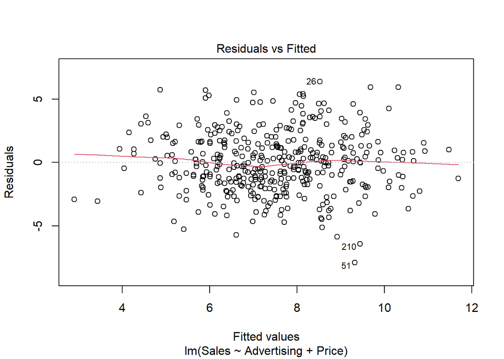

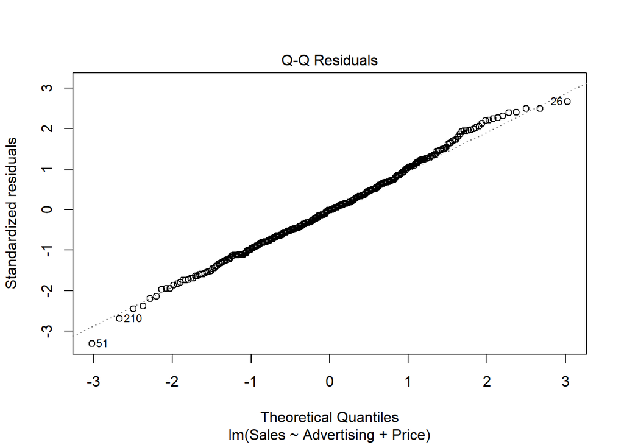

```r
plot(vanilla_lm, which = 1:2)
```

The estimated sample MSE of the model is 5.755201. During the modek fitting process we assume that the response varable (Sales) has a linear relationship with the predictor variable and that the erros are normally distributed, have constant variance, and are independent. Based off the plots every thing looks good, there are only 3 possible outliers. I am very satisfied with the model.